# MWU vs NW

1. Smoothing - where we evaluate the training points, based on seeing data X_train,Y_train, so they fit a smooth lipschitz funtion. The Lischitz constant is picked using a cross validation search on several candidates.
2. Extension. Based on the smoothing, each new point can be evaluated in a way that the lipschitz constant is reserved.

you can run this code on either "cpu" or "gpu".

We start by import crucial packages, make sure you have them installed.

```python
import torch
import time
import pandas as pd
import numpy as np
from math import ceil,log,pi,inf,cos,sin,sqrt
from sklearn.metrics.pairwise import euclidean_distances
from IPython.core.debugger import Tracer;
```

## 1. Smoothing

Smoothing finds an evaluation of the X_train data, such that keep a fixed Lipschitz constant, that minimze the overall loss of the observed data Y*train. $\Phi(\tilde{Y},Y) = \frac{1}{n}\sum*{i=1}^n ||y_i-\tilde{y_i}||$. fixing the Lipshitz constant, allow us to prevent over fitting. The main algorithm is in SmoothMWU. FindSolutionAndReport and Smooth functions are wrapping of the algorithms.

```python
gpu_num = 0
device = torch.device(f"cuda:{gpu_num}" if torch.cuda.is_available() else "cpu")
print(f"Running on {device}")
if torch.cuda.is_available():
    print(f"{torch.cuda.get_device_name(gpu_num)}")

eps = 0.1 #epsilon - the precision


# the running time can improved by a factor of 2
# since we don't have to compute both |y_i - y_j| and |y_j - y_i|
def PairwiseSqDistances(Y):
    #Y is is an N-by-dimB matrix
    [N, dimB] = list(Y.size())

    repY  = Y.unsqueeze(1).expand(N, N, dimB)
    repYt = repY.transpose(0, 1)
    return torch.sum((repY - repYt) ** 2, 2)
    #return torch.Tensor(euclidean_distances(Y)**2)


def findLipschitzConstant(X,Y):
    """
    given two sets of vectors of size n where f(X_i) = Y_i
    finds the Lipschitz constant of f over (X,Y).
    """

    #return (torch.max(PairwiseSqDistances(Y) / (PairwiseSqDistances(X)+torch.eye(X.size()[0],device = device)))).to(device)
    distY = torch.Tensor(euclidean_distances(Y,Y)**2)
    distX = torch.Tensor(euclidean_distances(X,X)**2)
    return  (torch.max(distY / (distX+torch.eye(distX.size()[0],device = device)))).to(device)

def SmoothMWU(Y, R_sq, Phi_0):
    # Y is an N-by-dimB matrix; Y^T from the write-up
    # R_sq is is an N-by-N matrix
#    from IPython.core.debugger import Tracer; Tracer()()
    [N, dimB] = list(Y.size())

    m = N*(N-1) // 2 # the number of pair of points,
    delta = eps / (2*m) #what is delta

    # Initialize the weight matrix
    w_Phi = 0.5
    W = torch.Tensor(N,N).to(device).fill_(0.5 / m)
    for i in range(N):
        R_sq[i,i] = 1 # why?

    T = 350 # used for speed, for better resalts use sqrt(m)*log(N)/eps**2)

    YSmoothed = torch.zeros(N, dimB, device = device) # returned output. initial guess

    for t in range(T):
        lambda_inv = Phi_0 / (w_Phi + eps/2) ## \lambda^{-1}

        # set off-diagonal entries

        L = -lambda_inv * torch.div(W + delta, R_sq)

        # set/fix the diagonal entries
        S = torch.sum(L, dim = 1)
        for i in range(N):
            L[i,i] += -S[i] + 1

        # solve for Yt ; gesv ==> solve in the next version of torch
        Yt, _ = torch.gesv(Y, L)
        YSmoothed *= t/(t+1)
        YSmoothed += Yt/(t+1)

        # update the weights
        # first update W, that is w_{ij}'s
        PD = PairwiseSqDistances(Yt)
        WUpdate = 1 + 2*eps * (torch.div(PD, R_sq) ** 0.5 - 1)
        W *= WUpdate

        # now update w_Phi
        WPhiUpdate = 1 + 2*eps * ((torch.sum((Y - Yt) ** 2) / Phi_0) ** 0.5  - 1)
        w_Phi *= WPhiUpdate

        # renormalize
        for i in range(N):
            W[i,i] = 0

        TotalW = torch.sum(W) / 2 + w_Phi
        W /= TotalW
        w_Phi /= TotalW

    return YSmoothed

def Smooth(Y, R_sq):
    [N, dimB] = list(Y.size())
    YMean = (torch.sum(Y, dim = 1) / N).unsqueeze(1).expand(N, dimB)

    Phi_0 = torch.sum((Y - YMean) ** 2) #a very crude upper bound

    PhiUB = Phi_0
    PhiLB = 0

    while (PhiUB > (1 + eps/10) * PhiLB):
        print("<", end = "")
        Phi_0 = (PhiLB + PhiUB) / 2
        YSmoothed = SmoothMWU(Y, R_sq, Phi_0)
        bLip = ( PairwiseSqDistances(YSmoothed) < (1 + eps) * R_sq ).all()
        #bLip = ( PairwiseSqDistances(YSmoothed) < (1 + eps) * R_sq ).all()
        bPhi = (torch.sum((Y - YSmoothed) ** 2) / Phi_0) < 1 + 2 * eps

        if bLip and bPhi:
            PhiUB = Phi_0
        else:
            PhiLB = Phi_0
        print(">", end = "", flush = True)

    print()
    return SmoothMWU(Y, R_sq, PhiUB)

def FindSolutionAndReport(Y, X,Lip, bReportVectors=True):
    R_sq = PairwiseSqDistances(X)
    #R_sq = torch.Tensor(euclidean_distances(X,X))
    StartTime = time.time()
    YSmoothed = Smooth(Y,Lip * R_sq)
    phi = torch.mean((Y - YSmoothed) ** 2).item()
    #d,n = X.size()[1]+Y.size()[1],X.size()[0] # important for risk bound using Rademacher complexity
    #k = ( (d-1)*34*(4*Lip)**(d/2) ) / ( 2*sqrt(n) )
    #rad = 8*k**(1/(d+1)) + d*k**((d-1)/(d+1)) - 2*(-(d+1)/2)
    #rad_bound = phi+rad
    print("Phi: ", phi)#, " Rad:", rad, " Bound: ",rad_bound)
    print("Lipschitz constant ",findLipschitzConstant(X,YSmoothed))
    if bReportVectors:
        print("vectors:", YSmoothed)

    print("Elapsed time", round(time.time()- StartTime,2), " sec")
    return YSmoothed #, rad_bound
```

```
Running on cpu
```

## 2. Extension

The extension evaluate a new point $x \in X$ that preserved the lipschitz constant of the Z_train set

```python
def nearestNeighbor(x,X,Y):
#NEARESTNEIGHBOR finds the nearest neighbor and it's distance
#   x - a vector
#   X - group of vectors represented as row vectors.
#   returns the nearest neigbor of x in X, the ditance ||x-nn||, and
#   y0=f(x0)

    N = X.size()[0]; # number of vectors in X
    difference = torch.norm(X-x.repeat(N,1),dim=1)
    dist,i = torch.min(difference),torch.argmin(difference)
    nn = X[i,:]
    y0 = Y[i,:]
    return dist,y0

def extension(x,X,Y,eps,L):
    # extension finds a (1+eps) Lipshitz approximation for z=h(x)
    #   x = the query point (vector)
    #   X = the training set samples
    #   Y = the training set labeling (not the true lables). actualy Y=Z
    #   eps = the approximation parameter. in (0,1/2)
    #   z = the output , the extension of h to x. z=h(x) s.t the lipshitz
    #   constnant is less then (1+eps)L
    ## the marks numbers are for being consistent with the paper of the work.

    # basic parameters
    n = X.size()[0]; # sample size
    DOF2 = Y.size()[1] # dimension of Y

    #1. find nearest neighbour of x out of X; y0 = f(x0) ; d0 = ||x0-x||
    d0,y0 = nearestNeighbor(x,X,Y)
    #2. T is nuber of iterations
    T = 1000 # for better results use torch.min(ceil(16*log(n)/eps**2)
    #3. initialize weights vector w where w1=1/n for each i
    w = torch.ones(n,T+1).to(device)*1/n;
    #4. initialize distance vector d where di = ||xi - x||
    d = L*torch.norm(X-x.repeat(n,1),dim=1)
    #5. Steps 6-10 will be repeated until convergence
    for t in range(T):
        #6. create a distribution
        P = torch.sum(w[:,t]/(d**2)); #normaplization parameter
        p = w[:,t]/(P*(d**2));
        #7. z0 = sum(pi*yi) and delta = ||z0-y0||
        z0 = torch.sum(Y*p.repeat(DOF2,1).transpose(0,1),dim=0)
        delta = torch.norm(z0-y0);
        #8. evalute z
        if delta <= d0:
            z = z0
        else:
            z = d0/delta*z0+(delta-d0)/delta*y0
        #9. update weights : wi(t+1) = (1+(eps*||z-yi||/8di))*wi(t) for all i
        tmp_dist = torch.norm(z.repeat(n,1)-Y,dim=1)
        w[:,t+1]=torch.ones(n,device=device)+eps*tmp_dist/(8*d)*w[:,t]
        #10. normalize the weitghts
        W = torch.sum(w[:,t+1]);
        w[:,t+1] = (1/W)*w[:,t+1];
    #11. average over weights
    final_w = torch.sum(w,dim=1)*1/(T+1);
    #12. compute z as in 6-8
    #6.
    P = torch.sum(final_w*(d**2)); #normaplization parameter
    p = final_w/(P*(d**2));
    #7. z0 = sum(pi*yi) and delta = ||z0-y0||
    z0 = torch.sum(Y*p.repeat(DOF2,1).transpose(0,1),dim=0)
    delta = torch.norm(z0-y0);
    #8. evalute z
    if delta <= d0:
        z = z0
    else:
        z = d0/delta*z0+(delta-d0)/delta*y0
    return z

def Test(X_val,X_train,Z_train,eps,l):
    n_val = X_val.size()[0] # validation/test set size
    DOF2 = Z_train.size()[1];    # dimension of Y, the second agent
    Z_val = torch.ones(n_val,DOF2).to(device)
    for i in range(n_val):
        x0 = X_val[i]
        Z_val[i] = extension(x0,X_train,Z_train,eps,l)
#debug        print(Z_val[i])
    return Z_val
```

## 3. Train and Test

the next section is for using the algorithm in order to train and test the algorithm. The training consist of finding the optimal Lipshchitz $l$ constant using cross validation over different $l$ candidates. We also used the Structur Risk Minimization (SRM) which finds the $l$ which yields to the smallest generalization bound, but in practice this factor is non informative unless n is on a very large scale (milions). It is likely the SRM will be deleted in future for now you can uncomment it for your own use

```python
def lstsqrs(Z,Y):
    ### will return the distance phi = sum(||Z-Y||**2)
    ### when dealing with angels we notice that distance(0,2pi) = 0
    N = Z.size()[0]
    return torch.sum(torch.norm(Z-Y,dim=1)**2)/N


#mod_lstqr consider the periodic of distance between angles
def mod_lstsqr(Z,Y):
    ### will return the distance phi = sum(||Z-Y||**2)
    ### when dealing with angels we notice that distance(0,2pi) = 0
    diff = torch.min((Z-Y)%(2*pi),(Y-Z)%(2*pi))
    dist = torch.norm(diff,dim=1)**2
    return dist.mean()

def crossVal(X,Y,X_val,Y_val,k_fold = 10):
    #basic parameters
    N,DOF1 = X.size();
    DOF2 = Y.size()[1];
    N_val = X_val.size()[0]
    lip = findLipschitzConstant(X,Y)
    L = torch.exp(torch.linspace(0,torch.log(lip),k_fold))
    StartTime = time.time()

    #important values

    no_improvement  = 0
    lip_const  = inf #the returned lipschitz constant of the CV process
    Phi = inf # the returned score score sum(||Y_i-Z_i||)/N ,
    Z_train = torch.zeros(Y.size()), #the returned smoothing

    for l in L:
        tmp_time = time.time()
        Z_train_l = FindSolutionAndReport(Y,X,l,False) # smoothig by l
        Z_val = Test(X_val,X,Z_train,eps,l) # validating
        Phi_l = lstsqrs(Z_val,Y_val)
        print("lip ",l," Phi = ",Phi_l, "time = ", round(time.time()- tmp_time,2), "sec")

        if Phi_l < Phi:
            Phi = Phi_l
            lip_const = l
            Z_train = Z_train_l
            no_improvement = 0

        else:
            no_improvement += 1

        if no_improvement >= 2: # if it is the second time it means we start over fitting so we stop
            print("lip ",l," Phi = ",Phi_l, "time = ", round(time.time()- tmp_time,2), "sec")
            print("We start overfitting the data")
            break


    print("finished training ",N," points ",k_fold,"crossValidation in ",round(time.time()- StartTime,2)," sec")
    print("Lip_const_cv: l=", lip_const," with score: Phi=",Phi)

    return Z_train,lip_const
```

For Testing our model, we first import the data, which should be allocated in a directory named data - placed in the same directory as this code file

```python
# if you want to learn py positioning (may lead to distortions)
N_train = 10000
N_test = 100
data_dir = 'data_3to5_positions'
X = torch.Tensor(np.array(pd.read_csv(data_dir+'\posX_train.csv', header = None))[:N_train,:]).to(device)
Y = torch.Tensor(np.array(pd.read_csv(data_dir+'\posY_train.csv', header = None))[:N_train,:]).to(device)
#noise = torch.randn(Y.size()) * Y.std()/10
#Y = Y + noise
X_test = torch.Tensor(np.array(pd.read_csv(data_dir+'\posX_test.csv', header = None))[:N_test,:]).to(device)
Y_test = torch.Tensor(np.array(pd.read_csv(data_dir+'\posY_test.csv', header = None))[:N_test,:]).to(device)
```

```python
#TODO: this temporary box should be integrated in the cross validation function
from random import sample
train_size = N_train*9//10
R = sample(range(N_train),train_size+train_size//10)
I,J = R[:train_size],R[train_size:]
X_train,X_val = X[I],X[J]
Y_train,Y_val = Y[I],Y[J]
```

For thousands of points running time of FindAndReport could be in hours. therefor we find the Lipschitz constant via Cross valditaion over only part of the training set. Once we picked the lip_const of the problem, we can train smooth the entire training set.

```python
#CV_N = 1000
Z_train,lip_const = crossVal(X_train,Y_train,X_val,Y_val,k_fold=10)
```

[output not shown]

```python
Z_train =  FindSolutionAndReport(Y_train,X_train,lip_const,False)
```

[output not shown]

Use the following code if you already run the algorithm and\or want to save time for the exploration part

```python
Z_train = torch.Tensor(np.array(pd.read_csv(data_dir+'\Z_train.csv', header = None))[:N_train,:]).to(device)
Z_test = torch.Tensor(np.array(pd.read_csv(data_dir+'\Z_test_mw.csv', header = None))[:N_test,:]).to(device)
#lip_const = findLipschitzConstant(X_train,Z_train)
```

```python
startTime = time.time()
Z_test = Test(X_test,X_train,Z_train,eps,lip_const)
print("Test ",Z_test.size()[0],"samples in ",  round(time.time()- startTime,2)," sec.")
```

[output not shown]

Let's see how we did.

```python
print("AVG lstsqrs: ",lstsqrs(Z_test,Y_test)/N_test)
```

```
AVG lstsqrs:  0.0008803805351257324
```

## Nadaraya Watson

```python
def lstsqrs(Y_hat,Y):
    ### will return the distance phi = sum(||Z-Y||**2)
    ### when dealing with angels we notice that distance(0,2pi) = 0
    N = Y_hat.shape[0]
    return np.sum(np.linalg.norm(Y_hat-Y,axis=1)**2)/N

def K0(X,x,h):
    #gets a vector and returns 1 if the condition is held
    ind = np.linalg.norm((X - x),axis=1)/h < 1 # indicator
    return ind.astype(int)

def Rec_Kernel(X,x,h):
    1/2*K0(X,x,h)


def gau_Kernel(X,x,h, sigma2 = 1):
    dist = np.linalg.norm((X-x),axis=1)**2
    exp = np.exp(dist/sigma2)
    return exp

def f_NW(X,Y,x,Kernel,h=1):
    #X and Y are the training set and labels, x a new point,K is a Kernel, h is the bandwith
    K = Kernel(X,x,h)
    nominator = np.sum( np.transpose(Y.transpose() * K ),axis = 0)
    deliminator = sum(K)
    return (0 if deliminator== 0 else nominator/deliminator)

def predict(X_tr,Y_tr,X_test,Kernel = K0, h = 1):
    n,d = X_test.shape[0],Y_tr.shape[1]
    Y_hat = np.zeros([n,d])
    for i in range(n):
        x = X_test[i]
        Y_hat[i] = f_NW(X_tr,Y_tr,x,Kernel)
    return Y_hat

def fit(X,Y,Kernel = K0 , k_fold = 20):
    #retruns the optimal bandwith h
    if k_fold < 1: k_fold = 1
    n = X.shape[0] #sample size
    H = np.linspace(0.0001,1,k_fold)
    j = 0
    lst_sqr = np.zeros(k_fold)
    timer = time.time()
    print("Strat fitting the data")
    for h in H:
        start = time.time()
        print("fitting h=",h)
        lst_l = 0
        for i in range(2): # we will do 10 random ordering validation on each h for better consistency with the results
            shuffle = np.random.permutation(range(n))
            N_train = n*9//10
            X_train,X_val = X[shuffle[:N_train]],X[shuffle[N_train:]]
            Y_train,Y_val = Y[shuffle[:N_train]],Y[shuffle[N_train:]]
            Y_hat = predict(X_train,Y_train,X_val,Kernel,h)
            lst_sqr[j] = lst_sqr[j] + lstsqrs(Y_hat,Y_val)
        lst_sqr[j] = lst_sqr[j]/10
        end = time.time()
        #print("finished with score: ", lst_sqr[j]," time: ",(end - start))
        j = j+1
    h_opt = H[np.argmin(lst_sqr)]
    end = time.time()
    print("Finished fitting in: ", (end - timer)," Optimal h: ", h_opt)
    return h_opt
```

```python
h = fit(X.numpy(),Y.numpy(),Kernel = gau_Kernel)
```

```
Strat fitting the data
fitting h= 0.0001
fitting h= 0.05272631578947369
fitting h= 0.10535263157894738
fitting h= 0.15797894736842105
fitting h= 0.21060526315789474
fitting h= 0.2632315789473684
fitting h= 0.3158578947368421
fitting h= 0.3684842105263158
fitting h= 0.4211105263157895
fitting h= 0.4737368421052632
fitting h= 0.5263631578947369
fitting h= 0.5789894736842105
fitting h= 0.6316157894736842
fitting h= 0.684242105263158
fitting h= 0.7368684210526316
fitting h= 0.7894947368421052
fitting h= 0.842121052631579
fitting h= 0.8947473684210527
fitting h= 0.9473736842105264
fitting h= 1.0
Finished fitting in:  0.24217677116394043  Optimal h:  0.15797894736842105
```

```python
Y_hat_test = predict(X.numpy(),Y.numpy(),X_test.numpy(),h=h)
lstsqrs(Y_hat_test,Y_test.numpy())
```

```
0.16252595971310704
```

## plot

```python
import matplotlib.pyplot as plt
```

```python
def plot4Arms(arm1,arm2,arm3,arm4):
    x1,y1 = arm1[0::2],arm1[1::2] #expert
    x2,y2 = arm2[0::2],arm2[1::2]
    x3,y3 = arm3[0::2],arm3[1::2]
    x4,y4 = arm4[0::2],arm4[1::2]
    plt.plot(x1,y1,linestyle = '-',marker='o',color = 'k',linewidth=3) # expert (k link)
    plt.plot(x2,y2,linestyle = '--',marker='o',color = 'r',linewidth=3) # true (d link)
    plt.plot(x3,y3,linestyle = '-',marker='o',color = 'y',linewidth=3) # competetor (d link)
    plt.plot(x4,y4,linestyle = '-',marker='o',color = 'b',linewidth=3) # MWU (d link)

def plot3Arms(arm1,arm2,arm3):
    x1,y1 = arm1[0::2],arm1[1::2]
    x2,y2 = arm2[0::2],arm2[1::2]
    x3,y3 = arm3[0::2],arm3[1::2]
    plt.plot(x1,y1,linestyle = '--',marker='o',color = 'r',linewidth=3) #true
    plt.plot(x2,y2,linestyle = '-',marker='o',color = 'g',linewidth=3) #competetor
    plt.plot(x3,y3,linestyle = '-',marker='o',color = 'b',linewidth=3) #MWU

def plot2Arms(arm1,arm2):
    x1,y1 = arm1[0::2],arm1[1::2]
    x2,y2 = arm2[0::2],arm2[1::2]
    plt.plot(x1,y1,linestyle = '--',marker='o',color = 'r',linewidth=3) #true
    plt.plot(x2,y2,linestyle = '-',marker='o',color = 'k',linewidth=3) #learner
```

We can examine the MW learner final positions (where it matters), ploting the learned correspondence. We will plot 2 arms on the same figure:

```
5 :
```

[figure not shown]

```
15 :
```

[figure not shown]

```
19 :
```

[figure not shown]

```
28 :
```

[figure not shown]

```python
I = [5,15,19,28] #sample(range(N_test),20); # change for as much figures you want to plot
for i in I:
    print(i,":")
    plot2Arms(Y_test[i].numpy(),Z_test[i].numpy())
    ax = plt.gca()
    ax.spines['left'].set_position('zero')
    ax.spines['right'].set_color('none')
    ax.spines['bottom'].set_position('zero')
    ax.spines['top'].set_color('none')
    plt.axis('equal')
    plt.show()
    plt.clf()
```

We can examine the MW learner final positions vs the NW, ploting the learned correspondence by each algorithm. We will plot 3 arms on the same figure:

```
5 :
```

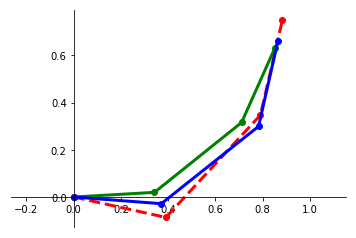

```
15 :
```

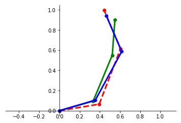

```
19 :
```

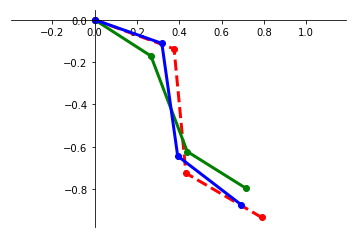

```
28 :
```

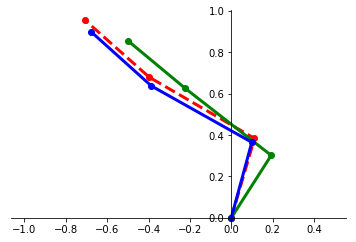

```python
I = [5,15,19,28]# change for as much figures you want to plot
for i in I:
    plt.clf()
    print(i,":")
    plot3Arms(Y_test[i].numpy() , Y_hat_test[i], Z_test[i].numpy())
    ax = plt.gca()
    ax.spines['left'].set_position('zero')
    ax.spines['right'].set_color('none')
    ax.spines['bottom'].set_position('zero')
    ax.spines['top'].set_color('none')
    plt.axis('equal')
    plt.show()
    plt.clf()
```

```
0 :
```

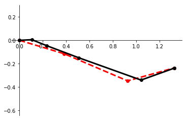

```
1 :
```

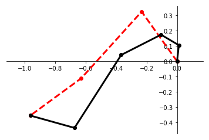

```
2 :
```

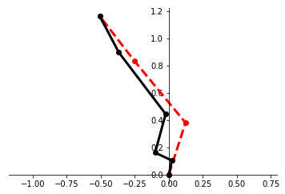

```
3 :
```

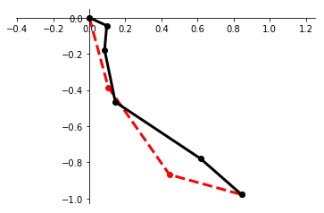

```
4 :
```

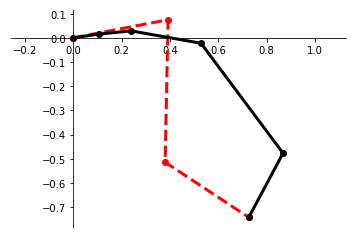

```python
I = range(5) # change for as much figures you want to plot
for i in I:
    plt.clf()
    print(i,":")
    plot2Arms(Y_test[i].numpy() , X_test[i].numpy())
    ax = plt.gca()
    ax.spines['left'].set_position('zero')
    ax.spines['right'].set_color('none')
    ax.spines['bottom'].set_position('zero')
    ax.spines['top'].set_color('none')
    plt.axis('equal')
    plt.show()
    plt.clf()
```